# Risk Factor Analysis

## Outcome Variable

**Outcome Variable:** haz

## Predictor Variables

**Intervention Variable:** safeh20

**Adjustment Set:**

unadjusted

## Stratifying Variables

The analysis was stratified on these variable(s):

- agecat
- studyid
- country

## Data Summary

| agecat | studyid | country | safeh20 | n_cell | n |
| --- | --- | --- | --- | --- | --- |
| Birth | ki0047075b-MAL-ED | BANGLADESH | 1 | 0 | 234 |
| Birth | ki0047075b-MAL-ED | BANGLADESH | 0 | 234 | 234 |
| Birth | ki0047075b-MAL-ED | BRAZIL | 1 | 0 | 124 |
| Birth | ki0047075b-MAL-ED | BRAZIL | 0 | 124 | 124 |
| Birth | ki0047075b-MAL-ED | INDIA | 1 | 0 | 191 |
| Birth | ki0047075b-MAL-ED | INDIA | 0 | 191 | 191 |
| Birth | ki0047075b-MAL-ED | NEPAL | 1 | 1 | 168 |
| Birth | ki0047075b-MAL-ED | NEPAL | 0 | 167 | 168 |
| Birth | ki0047075b-MAL-ED | PERU | 1 | 9 | 247 |
| Birth | ki0047075b-MAL-ED | PERU | 0 | 238 | 247 |
| Birth | ki0047075b-MAL-ED | SOUTH AFRICA | 1 | 33 | 216 |
| Birth | ki0047075b-MAL-ED | SOUTH AFRICA | 0 | 183 | 216 |
| Birth | ki0047075b-MAL-ED | TANZANIA, UNITED REPUBLIC OF | 1 | 79 | 118 |
| Birth | ki0047075b-MAL-ED | TANZANIA, UNITED REPUBLIC OF | 0 | 39 | 118 |
| Birth | ki1017093-NIH-Birth | BANGLADESH | 1 | 28 | 28 |
| Birth | ki1017093-NIH-Birth | BANGLADESH | 0 | 0 | 28 |
| Birth | ki1017093c-NIH-Crypto | BANGLADESH | 1 | 27 | 27 |
| Birth | ki1017093c-NIH-Crypto | BANGLADESH | 0 | 0 | 27 |
| Birth | kiGH5241-JiVitA-3 | BANGLADESH | 1 | 19558 | 19593 |
| Birth | kiGH5241-JiVitA-3 | BANGLADESH | 0 | 35 | 19593 |
| Birth | kiGH5241-JiVitA-4 | BANGLADESH | 1 | 822 | 822 |
| Birth | kiGH5241-JiVitA-4 | BANGLADESH | 0 | 0 | 822 |
| 6 months | ki0047075b-MAL-ED | BANGLADESH | 1 | 0 | 240 |
| 6 months | ki0047075b-MAL-ED | BANGLADESH | 0 | 240 | 240 |
| 6 months | ki0047075b-MAL-ED | BRAZIL | 1 | 0 | 142 |
| 6 months | ki0047075b-MAL-ED | BRAZIL | 0 | 142 | 142 |
| 6 months | ki0047075b-MAL-ED | INDIA | 1 | 0 | 235 |
| 6 months | ki0047075b-MAL-ED | INDIA | 0 | 235 | 235 |
| 6 months | ki0047075b-MAL-ED | NEPAL | 1 | 1 | 233 |
| 6 months | ki0047075b-MAL-ED | NEPAL | 0 | 232 | 233 |
| 6 months | ki0047075b-MAL-ED | PERU | 1 | 11 | 259 |
| 6 months | ki0047075b-MAL-ED | PERU | 0 | 248 | 259 |
| 6 months | ki0047075b-MAL-ED | SOUTH AFRICA | 1 | 37 | 248 |
| 6 months | ki0047075b-MAL-ED | SOUTH AFRICA | 0 | 211 | 248 |
| 6 months | ki0047075b-MAL-ED | TANZANIA, UNITED REPUBLIC OF | 1 | 168 | 246 |
| 6 months | ki0047075b-MAL-ED | TANZANIA, UNITED REPUBLIC OF | 0 | 78 | 246 |
| 6 months | ki1000304b-SAS-FoodSuppl | INDIA | 1 | 380 | 380 |
| 6 months | ki1000304b-SAS-FoodSuppl | INDIA | 0 | 0 | 380 |
| 6 months | ki1017093-NIH-Birth | BANGLADESH | 1 | 535 | 537 |
| 6 months | ki1017093-NIH-Birth | BANGLADESH | 0 | 2 | 537 |
| 6 months | ki1017093b-PROVIDE | BANGLADESH | 1 | 581 | 581 |
| 6 months | ki1017093b-PROVIDE | BANGLADESH | 0 | 0 | 581 |
| 6 months | ki1017093c-NIH-Crypto | BANGLADESH | 1 | 715 | 715 |
| 6 months | ki1017093c-NIH-Crypto | BANGLADESH | 0 | 0 | 715 |
| 6 months | ki1114097-CONTENT | PERU | 1 | 54 | 57 |
| 6 months | ki1114097-CONTENT | PERU | 0 | 3 | 57 |
| 6 months | ki1148112-LCNI-5 | MALAWI | 1 | 672 | 816 |
| 6 months | ki1148112-LCNI-5 | MALAWI | 0 | 144 | 816 |
| 6 months | kiGH5241-JiVitA-3 | BANGLADESH | 1 | 16783 | 16803 |
| 6 months | kiGH5241-JiVitA-3 | BANGLADESH | 0 | 20 | 16803 |
| 6 months | kiGH5241-JiVitA-4 | BANGLADESH | 1 | 4824 | 4825 |
| 6 months | kiGH5241-JiVitA-4 | BANGLADESH | 0 | 1 | 4825 |
| 24 months | ki0047075b-MAL-ED | BANGLADESH | 1 | 0 | 212 |
| 24 months | ki0047075b-MAL-ED | BANGLADESH | 0 | 212 | 212 |
| 24 months | ki0047075b-MAL-ED | BRAZIL | 1 | 0 | 113 |
| 24 months | ki0047075b-MAL-ED | BRAZIL | 0 | 113 | 113 |
| 24 months | ki0047075b-MAL-ED | INDIA | 1 | 0 | 227 |
| 24 months | ki0047075b-MAL-ED | INDIA | 0 | 227 | 227 |
| 24 months | ki0047075b-MAL-ED | NEPAL | 1 | 1 | 226 |
| 24 months | ki0047075b-MAL-ED | NEPAL | 0 | 225 | 226 |
| 24 months | ki0047075b-MAL-ED | PERU | 1 | 7 | 193 |
| 24 months | ki0047075b-MAL-ED | PERU | 0 | 186 | 193 |
| 24 months | ki0047075b-MAL-ED | SOUTH AFRICA | 1 | 34 | 237 |
| 24 months | ki0047075b-MAL-ED | SOUTH AFRICA | 0 | 203 | 237 |
| 24 months | ki0047075b-MAL-ED | TANZANIA, UNITED REPUBLIC OF | 1 | 145 | 213 |
| 24 months | ki0047075b-MAL-ED | TANZANIA, UNITED REPUBLIC OF | 0 | 68 | 213 |
| 24 months | ki1017093-NIH-Birth | BANGLADESH | 1 | 427 | 429 |
| 24 months | ki1017093-NIH-Birth | BANGLADESH | 0 | 2 | 429 |
| 24 months | ki1017093b-PROVIDE | BANGLADESH | 1 | 576 | 576 |
| 24 months | ki1017093b-PROVIDE | BANGLADESH | 0 | 0 | 576 |
| 24 months | ki1017093c-NIH-Crypto | BANGLADESH | 1 | 514 | 514 |
| 24 months | ki1017093c-NIH-Crypto | BANGLADESH | 0 | 0 | 514 |
| 24 months | ki1114097-CONTENT | PERU | 1 | 45 | 48 |
| 24 months | ki1114097-CONTENT | PERU | 0 | 3 | 48 |
| 24 months | ki1148112-LCNI-5 | MALAWI | 1 | 475 | 574 |
| 24 months | ki1148112-LCNI-5 | MALAWI | 0 | 99 | 574 |
| 24 months | kiGH5241-JiVitA-3 | BANGLADESH | 1 | 8612 | 8623 |
| 24 months | kiGH5241-JiVitA-3 | BANGLADESH | 0 | 11 | 8623 |
| 24 months | kiGH5241-JiVitA-4 | BANGLADESH | 1 | 4746 | 4747 |
| 24 months | kiGH5241-JiVitA-4 | BANGLADESH | 0 | 1 | 4747 |

The following strata were considered:

- agecat: 24 months, studyid: ki0047075b-MAL-ED, country: BANGLADESH
- agecat: 24 months, studyid: ki0047075b-MAL-ED, country: BRAZIL
- agecat: 24 months, studyid: ki0047075b-MAL-ED, country: INDIA
- agecat: 24 months, studyid: ki0047075b-MAL-ED, country: NEPAL
- agecat: 24 months, studyid: ki0047075b-MAL-ED, country: PERU
- agecat: 24 months, studyid: ki0047075b-MAL-ED, country: SOUTH AFRICA
- agecat: 24 months, studyid: ki0047075b-MAL-ED, country: TANZANIA, UNITED REPUBLIC OF
- agecat: 24 months, studyid: ki1017093-NIH-Birth, country: BANGLADESH
- agecat: 24 months, studyid: ki1017093b-PROVIDE, country: BANGLADESH
- agecat: 24 months, studyid: ki1017093c-NIH-Crypto, country: BANGLADESH
- agecat: 24 months, studyid: ki1114097-CONTENT, country: PERU
- agecat: 24 months, studyid: ki1148112-LCNI-5, country: MALAWI
- agecat: 24 months, studyid: kiGH5241-JiVitA-3, country: BANGLADESH
- agecat: 24 months, studyid: kiGH5241-JiVitA-4, country: BANGLADESH
- agecat: 6 months, studyid: ki0047075b-MAL-ED, country: BANGLADESH
- agecat: 6 months, studyid: ki0047075b-MAL-ED, country: BRAZIL
- agecat: 6 months, studyid: ki0047075b-MAL-ED, country: INDIA
- agecat: 6 months, studyid: ki0047075b-MAL-ED, country: NEPAL
- agecat: 6 months, studyid: ki0047075b-MAL-ED, country: PERU
- agecat: 6 months, studyid: ki0047075b-MAL-ED, country: SOUTH AFRICA
- agecat: 6 months, studyid: ki0047075b-MAL-ED, country: TANZANIA, UNITED REPUBLIC OF
- agecat: 6 months, studyid: ki1000304b-SAS-FoodSuppl, country: INDIA
- agecat: 6 months, studyid: ki1017093-NIH-Birth, country: BANGLADESH
- agecat: 6 months, studyid: ki1017093b-PROVIDE, country: BANGLADESH
- agecat: 6 months, studyid: ki1017093c-NIH-Crypto, country: BANGLADESH
- agecat: 6 months, studyid: ki1114097-CONTENT, country: PERU
- agecat: 6 months, studyid: ki1148112-LCNI-5, country: MALAWI
- agecat: 6 months, studyid: kiGH5241-JiVitA-3, country: BANGLADESH
- agecat: 6 months, studyid: kiGH5241-JiVitA-4, country: BANGLADESH
- agecat: Birth, studyid: ki0047075b-MAL-ED, country: BANGLADESH
- agecat: Birth, studyid: ki0047075b-MAL-ED, country: BRAZIL
- agecat: Birth, studyid: ki0047075b-MAL-ED, country: INDIA
- agecat: Birth, studyid: ki0047075b-MAL-ED, country: NEPAL
- agecat: Birth, studyid: ki0047075b-MAL-ED, country: PERU
- agecat: Birth, studyid: ki0047075b-MAL-ED, country: SOUTH AFRICA
- agecat: Birth, studyid: ki0047075b-MAL-ED, country: TANZANIA, UNITED REPUBLIC OF
- agecat: Birth, studyid: ki1017093-NIH-Birth, country: BANGLADESH
- agecat: Birth, studyid: ki1017093c-NIH-Crypto, country: BANGLADESH
- agecat: Birth, studyid: kiGH5241-JiVitA-3, country: BANGLADESH
- agecat: Birth, studyid: kiGH5241-JiVitA-4, country: BANGLADESH

### Dropped Strata

- agecat: Birth, studyid: ki0047075b-MAL-ED, country: BANGLADESH
- agecat: Birth, studyid: ki0047075b-MAL-ED, country: BRAZIL
- agecat: Birth, studyid: ki0047075b-MAL-ED, country: INDIA
- agecat: Birth, studyid: ki0047075b-MAL-ED, country: NEPAL
- agecat: Birth, studyid: ki1017093-NIH-Birth, country: BANGLADESH
- agecat: Birth, studyid: ki1017093c-NIH-Crypto, country: BANGLADESH
- agecat: Birth, studyid: kiGH5241-JiVitA-4, country: BANGLADESH
- agecat: 6 months, studyid: ki0047075b-MAL-ED, country: BANGLADESH
- agecat: 6 months, studyid: ki0047075b-MAL-ED, country: BRAZIL
- agecat: 6 months, studyid: ki0047075b-MAL-ED, country: INDIA
- agecat: 6 months, studyid: ki0047075b-MAL-ED, country: NEPAL
- agecat: 6 months, studyid: ki1000304b-SAS-FoodSuppl, country: INDIA
- agecat: 6 months, studyid: ki1017093-NIH-Birth, country: BANGLADESH
- agecat: 6 months, studyid: ki1017093b-PROVIDE, country: BANGLADESH
- agecat: 6 months, studyid: ki1017093c-NIH-Crypto, country: BANGLADESH
- agecat: 6 months, studyid: ki1114097-CONTENT, country: PERU
- agecat: 6 months, studyid: kiGH5241-JiVitA-4, country: BANGLADESH
- agecat: 24 months, studyid: ki0047075b-MAL-ED, country: BANGLADESH
- agecat: 24 months, studyid: ki0047075b-MAL-ED, country: BRAZIL
- agecat: 24 months, studyid: ki0047075b-MAL-ED, country: INDIA
- agecat: 24 months, studyid: ki0047075b-MAL-ED, country: NEPAL
- agecat: 24 months, studyid: ki1017093-NIH-Birth, country: BANGLADESH
- agecat: 24 months, studyid: ki1017093b-PROVIDE, country: BANGLADESH
- agecat: 24 months, studyid: ki1017093c-NIH-Crypto, country: BANGLADESH
- agecat: 24 months, studyid: ki1114097-CONTENT, country: PERU
- agecat: 24 months, studyid: kiGH5241-JiVitA-4, country: BANGLADESH

## Methods Detail

We’re interested in the causal parameters $E[Y_a]$ for all values of $a \in \mathcal{A}$. These parameters represent the mean outcome if, possibly contrary to fact, we intervened to set all units to have $A=a$. Under the randomization and positivity assumptions, these are identified by the statistical parameters $\psi_a=E_W[E_{Y|A,W}(Y|A=a,W)]$. In addition, we’re interested in the mean of $Y$, $E[Y]$ under no intervention (the observed mean). We will estimate these parameters by using SuperLearner to fit the relevant likelihood factors – $E_{Y|A,W}(Y|A=a,W)$ and $p(A=a|W)$, and then updating our likelihood fit using a joint TMLE.

For unadjusted analyses ($W=\{\}$), initial likelihoods were estimated using Lrnr_glm to estimate the simple $E(Y|A)$ and Lrnr_mean to estimate $p(A)$. For adjusted analyses, a small library containing Lrnr_glmnet, Lrnr_xgboost, and Lrnr_mean was used.

Having estimated these parameters, we will then use the delta method to estimate relative risks and attributable risks relative to a prespecified baseline level of $A$.

# Results Detail

## Results Plots

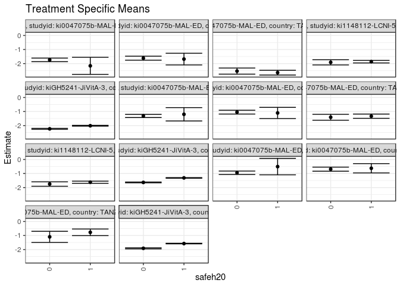

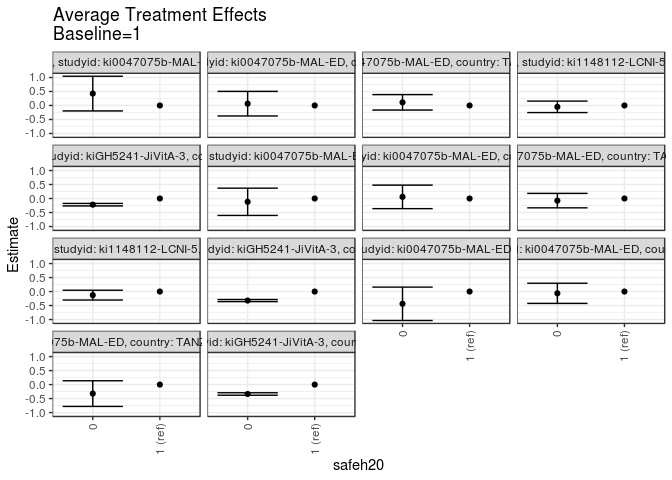

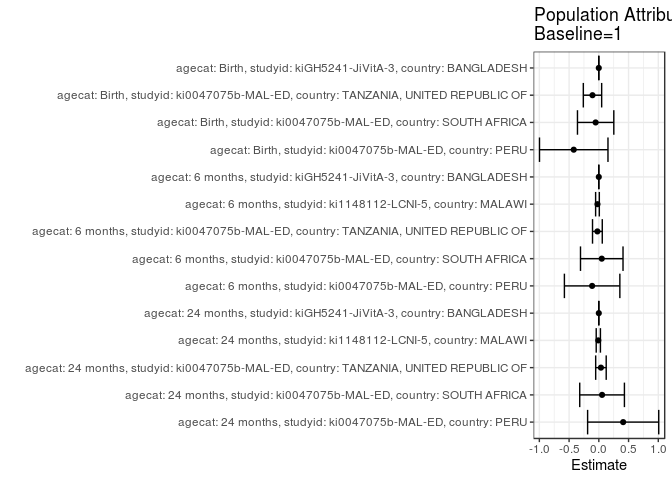

## Results Table

### Parameter: TSM

| agecat | studyid | country | intervention_level | baseline_level | estimate | ci_lower | ci_upper |
| --- | --- | --- | --- | --- | --- | --- | --- |
| Birth | ki0047075b-MAL-ED | PERU | 1 | NA | -0.5088889 | -1.0941264 | 0.0763486 |
| Birth | ki0047075b-MAL-ED | PERU | 0 | NA | -0.9466387 | -1.0665684 | -0.8267089 |
| Birth | ki0047075b-MAL-ED | SOUTH AFRICA | 1 | NA | -0.6284848 | -0.9586261 | -0.2983436 |
| Birth | ki0047075b-MAL-ED | SOUTH AFRICA | 0 | NA | -0.6916393 | -0.8365500 | -0.5467287 |
| Birth | ki0047075b-MAL-ED | TANZANIA, UNITED REPUBLIC OF | 1 | NA | -0.7745570 | -1.0089250 | -0.5401889 |
| Birth | ki0047075b-MAL-ED | TANZANIA, UNITED REPUBLIC OF | 0 | NA | -1.0966667 | -1.4914381 | -0.7018952 |
| Birth | kiGH5241-JiVitA-3 | BANGLADESH | 1 | NA | -1.5744130 | -1.5946607 | -1.5541653 |
| Birth | kiGH5241-JiVitA-3 | BANGLADESH | 0 | NA | -1.9108571 | -1.9500253 | -1.8716890 |
| 6 months | ki0047075b-MAL-ED | PERU | 1 | NA | -1.1977273 | -1.6713269 | -0.7241276 |
| 6 months | ki0047075b-MAL-ED | PERU | 0 | NA | -1.3152487 | -1.4283933 | -1.2021040 |
| 6 months | ki0047075b-MAL-ED | SOUTH AFRICA | 1 | NA | -1.1028604 | -1.5002774 | -0.7054433 |
| 6 months | ki0047075b-MAL-ED | SOUTH AFRICA | 0 | NA | -1.0447709 | -1.1809725 | -0.9085694 |
| 6 months | ki0047075b-MAL-ED | TANZANIA, UNITED REPUBLIC OF | 1 | NA | -1.3333036 | -1.4836412 | -1.1829660 |
| 6 months | ki0047075b-MAL-ED | TANZANIA, UNITED REPUBLIC OF | 0 | NA | -1.4087821 | -1.6186491 | -1.1989150 |
| 6 months | ki1148112-LCNI-5 | MALAWI | 1 | NA | -1.6200000 | -1.6970627 | -1.5429373 |
| 6 months | ki1148112-LCNI-5 | MALAWI | 0 | NA | -1.7486111 | -1.9061062 | -1.5911160 |
| 6 months | kiGH5241-JiVitA-3 | BANGLADESH | 1 | NA | -1.3128261 | -1.3365422 | -1.2891099 |
| 6 months | kiGH5241-JiVitA-3 | BANGLADESH | 0 | NA | -1.6345000 | -1.6633340 | -1.6056660 |
| 24 months | ki0047075b-MAL-ED | PERU | 1 | NA | -2.1600000 | -2.7672125 | -1.5527875 |
| 24 months | ki0047075b-MAL-ED | PERU | 0 | NA | -1.7351344 | -1.8622365 | -1.6080323 |
| 24 months | ki0047075b-MAL-ED | SOUTH AFRICA | 1 | NA | -1.6795588 | -2.0944198 | -1.2646978 |
| 24 months | ki0047075b-MAL-ED | SOUTH AFRICA | 0 | NA | -1.6156404 | -1.7581064 | -1.4731744 |
| 24 months | ki0047075b-MAL-ED | TANZANIA, UNITED REPUBLIC OF | 1 | NA | -2.6446897 | -2.8140679 | -2.4753114 |
| 24 months | ki0047075b-MAL-ED | TANZANIA, UNITED REPUBLIC OF | 0 | NA | -2.5328676 | -2.7511578 | -2.3145775 |
| 24 months | ki1148112-LCNI-5 | MALAWI | 1 | NA | -1.8630211 | -1.9535967 | -1.7724454 |
| 24 months | ki1148112-LCNI-5 | MALAWI | 0 | NA | -1.9119697 | -2.0957177 | -1.7282217 |
| 24 months | kiGH5241-JiVitA-3 | BANGLADESH | 1 | NA | -2.0122747 | -2.0406408 | -1.9839086 |
| 24 months | kiGH5241-JiVitA-3 | BANGLADESH | 0 | NA | -2.2327273 | -2.2682382 | -2.1972164 |

### Parameter: E(Y)

| agecat | studyid | country | intervention_level | baseline_level | estimate | ci_lower | ci_upper |
| --- | --- | --- | --- | --- | --- | --- | --- |
| Birth | ki0047075b-MAL-ED | PERU | NA | NA | -0.9306883 | -1.048645 | -0.8127312 |
| Birth | ki0047075b-MAL-ED | SOUTH AFRICA | NA | NA | -0.6819907 | -0.814754 | -0.5492274 |
| Birth | ki0047075b-MAL-ED | TANZANIA, UNITED REPUBLIC OF | NA | NA | -0.8810169 | -1.086924 | -0.6751103 |
| Birth | kiGH5241-JiVitA-3 | BANGLADESH | NA | NA | -1.5750140 | -1.594790 | -1.5552384 |
| 6 months | ki0047075b-MAL-ED | PERU | NA | NA | -1.3102574 | -1.420486 | -1.2000288 |
| 6 months | ki0047075b-MAL-ED | SOUTH AFRICA | NA | NA | -1.0534375 | -1.183632 | -0.9232428 |
| 6 months | ki0047075b-MAL-ED | TANZANIA, UNITED REPUBLIC OF | NA | NA | -1.3572358 | -1.479663 | -1.2348087 |
| 6 months | ki1148112-LCNI-5 | MALAWI | NA | NA | -1.6426961 | -1.712060 | -1.5733318 |
| 6 months | kiGH5241-JiVitA-3 | BANGLADESH | NA | NA | -1.3132090 | -1.336349 | -1.2900693 |
| 24 months | ki0047075b-MAL-ED | PERU | NA | NA | -1.7505440 | -1.875506 | -1.6255816 |
| 24 months | ki0047075b-MAL-ED | SOUTH AFRICA | NA | NA | -1.6248101 | -1.760608 | -1.4890121 |
| 24 months | ki0047075b-MAL-ED | TANZANIA, UNITED REPUBLIC OF | NA | NA | -2.6089906 | -2.743901 | -2.4740799 |
| 24 months | ki1148112-LCNI-5 | MALAWI | NA | NA | -1.8714634 | -1.952856 | -1.7900711 |
| 24 months | kiGH5241-JiVitA-3 | BANGLADESH | NA | NA | -2.0125560 | -2.040268 | -1.9848436 |

### Parameter: ATE

| agecat | studyid | country | intervention_level | baseline_level | estimate | ci_lower | ci_upper |
| --- | --- | --- | --- | --- | --- | --- | --- |
| Birth | ki0047075b-MAL-ED | PERU | 1 | 1 | 0.0000000 | 0.0000000 | 0.0000000 |
| Birth | ki0047075b-MAL-ED | PERU | 0 | 1 | -0.4377498 | -1.0351492 | 0.1596497 |
| Birth | ki0047075b-MAL-ED | SOUTH AFRICA | 1 | 1 | 0.0000000 | 0.0000000 | 0.0000000 |
| Birth | ki0047075b-MAL-ED | SOUTH AFRICA | 0 | 1 | -0.0631545 | -0.4236990 | 0.2973901 |
| Birth | ki0047075b-MAL-ED | TANZANIA, UNITED REPUBLIC OF | 1 | 1 | 0.0000000 | 0.0000000 | 0.0000000 |
| Birth | ki0047075b-MAL-ED | TANZANIA, UNITED REPUBLIC OF | 0 | 1 | -0.3221097 | -0.7812098 | 0.1369904 |
| Birth | kiGH5241-JiVitA-3 | BANGLADESH | 1 | 1 | 0.0000000 | 0.0000000 | 0.0000000 |
| Birth | kiGH5241-JiVitA-3 | BANGLADESH | 0 | 1 | -0.3364441 | -0.3805272 | -0.2923610 |
| 6 months | ki0047075b-MAL-ED | PERU | 1 | 1 | 0.0000000 | 0.0000000 | 0.0000000 |
| 6 months | ki0047075b-MAL-ED | PERU | 0 | 1 | -0.1175214 | -0.6044488 | 0.3694061 |
| 6 months | ki0047075b-MAL-ED | SOUTH AFRICA | 1 | 1 | 0.0000000 | 0.0000000 | 0.0000000 |
| 6 months | ki0047075b-MAL-ED | SOUTH AFRICA | 0 | 1 | 0.0580894 | -0.3620191 | 0.4781980 |
| 6 months | ki0047075b-MAL-ED | TANZANIA, UNITED REPUBLIC OF | 1 | 1 | 0.0000000 | 0.0000000 | 0.0000000 |
| 6 months | ki0047075b-MAL-ED | TANZANIA, UNITED REPUBLIC OF | 0 | 1 | -0.0754785 | -0.3336365 | 0.1826796 |
| 6 months | ki1148112-LCNI-5 | MALAWI | 1 | 1 | 0.0000000 | 0.0000000 | 0.0000000 |
| 6 months | ki1148112-LCNI-5 | MALAWI | 0 | 1 | -0.1286111 | -0.3039490 | 0.0467268 |
| 6 months | kiGH5241-JiVitA-3 | BANGLADESH | 1 | 1 | 0.0000000 | 0.0000000 | 0.0000000 |
| 6 months | kiGH5241-JiVitA-3 | BANGLADESH | 0 | 1 | -0.3216739 | -0.3589578 | -0.2843901 |
| 24 months | ki0047075b-MAL-ED | PERU | 1 | 1 | 0.0000000 | 0.0000000 | 0.0000000 |
| 24 months | ki0047075b-MAL-ED | PERU | 0 | 1 | 0.4248656 | -0.1955068 | 1.0452380 |
| 24 months | ki0047075b-MAL-ED | SOUTH AFRICA | 1 | 1 | 0.0000000 | 0.0000000 | 0.0000000 |
| 24 months | ki0047075b-MAL-ED | SOUTH AFRICA | 0 | 1 | 0.0639184 | -0.3747229 | 0.5025597 |
| 24 months | ki0047075b-MAL-ED | TANZANIA, UNITED REPUBLIC OF | 1 | 1 | 0.0000000 | 0.0000000 | 0.0000000 |
| 24 months | ki0047075b-MAL-ED | TANZANIA, UNITED REPUBLIC OF | 0 | 1 | 0.1118220 | -0.1644742 | 0.3881182 |
| 24 months | ki1148112-LCNI-5 | MALAWI | 1 | 1 | 0.0000000 | 0.0000000 | 0.0000000 |
| 24 months | ki1148112-LCNI-5 | MALAWI | 0 | 1 | -0.0489486 | -0.2538078 | 0.1559105 |
| 24 months | kiGH5241-JiVitA-3 | BANGLADESH | 1 | 1 | 0.0000000 | 0.0000000 | 0.0000000 |
| 24 months | kiGH5241-JiVitA-3 | BANGLADESH | 0 | 1 | -0.2204525 | -0.2650264 | -0.1758787 |

### Parameter: PAR

| agecat | studyid | country | intervention_level | baseline_level | estimate | ci_lower | ci_upper |
| --- | --- | --- | --- | --- | --- | --- | --- |
| Birth | ki0047075b-MAL-ED | PERU | 1 | NA | -0.4217994 | -0.9975224 | 0.1539237 |
| Birth | ki0047075b-MAL-ED | SOUTH AFRICA | 1 | NA | -0.0535059 | -0.3589823 | 0.2519706 |
| Birth | ki0047075b-MAL-ED | TANZANIA, UNITED REPUBLIC OF | 1 | NA | -0.1064600 | -0.2606603 | 0.0477403 |
| Birth | kiGH5241-JiVitA-3 | BANGLADESH | 1 | NA | -0.0006010 | -0.0017604 | 0.0005584 |
| 6 months | ki0047075b-MAL-ED | PERU | 1 | NA | -0.1125301 | -0.5787862 | 0.3537260 |
| 6 months | ki0047075b-MAL-ED | SOUTH AFRICA | 1 | NA | 0.0494229 | -0.3080175 | 0.4068632 |
| 6 months | ki0047075b-MAL-ED | TANZANIA, UNITED REPUBLIC OF | 1 | NA | -0.0239322 | -0.1059053 | 0.0580409 |
| 6 months | ki1148112-LCNI-5 | MALAWI | 1 | NA | -0.0226961 | -0.0538206 | 0.0084285 |
| 6 months | kiGH5241-JiVitA-3 | BANGLADESH | 1 | NA | -0.0003829 | -0.0013326 | 0.0005668 |
| 24 months | ki0047075b-MAL-ED | PERU | 1 | NA | 0.4094560 | -0.1885215 | 1.0074334 |
| 24 months | ki0047075b-MAL-ED | SOUTH AFRICA | 1 | NA | 0.0547487 | -0.3209760 | 0.4304734 |
| 24 months | ki0047075b-MAL-ED | TANZANIA, UNITED REPUBLIC OF | 1 | NA | 0.0356990 | -0.0527869 | 0.1241850 |
| 24 months | ki1148112-LCNI-5 | MALAWI | 1 | NA | -0.0084424 | -0.0438076 | 0.0269229 |
| 24 months | kiGH5241-JiVitA-3 | BANGLADESH | 1 | NA | -0.0002812 | -0.0014434 | 0.0008810 |